# Study Population Summary

July 22, 2025

Study population definiton: patients enrolled for at least 180 days in Kaiser data with an index dx coming from encounter types AV, ED, IP, or IS that had >= 70% of visits in [180,0] window with temp reading.

```
## # A tibble: 4 x 2
##   encounter_type     n
##   <chr>          <int>
## 1 LO                 7
## 2 OE               221
## 3 RO                 2
## 4 VC               175
```

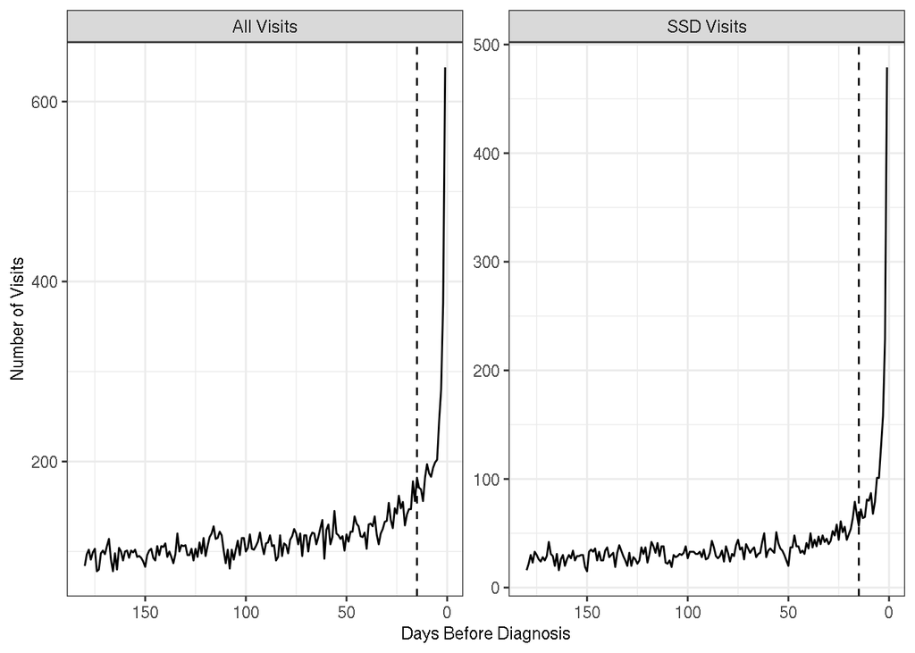

In the 180-days prior to the index diagnosis, 2678 patients of the total 3420 patients had at least one healthcare visit prior to the index for any reason. Break down of visits that occurred prior to index:

```
## # A tibble: 1 x 4
##   outpatient inpatient    ed other
##        <int>     <int> <int> <int>
## 1      19117       736  3032  5000
```

There were 742 patients whose first visit occurred on the index date. Of these patients whose first visit occurred on the index date, 742 had temperature reading on the index visit as well, with 112 (15.09%) patients having a fever based on a temp >= 100F.

Break down of visits that occurred on index for individuals whose first visit occurred on the index date:

```
## # A tibble: 4 x 3
##   Setting        n percent
##   <chr>      <int> <chr>
## 1 outpatient   322 19.78
## 2 inpatient    323 19.84
## 3 ed           724 44.47
## 4 other        259 15.91
```

Break down of visits that occurred on index for individuals whose first visit occurred on the index date and had a fever based on a temp >= 100F:

```
## # A tibble: 4 x 3
##   Setting        n percent
##   <chr>      <int> <chr>
## 1 outpatient    98 33.45
## 2 inpatient     54 18.43
## 3 ed           105 35.84
## 4 other         36 12.29
```

Break down of visits that occurred on index for individuals who had visits prior to index:

```
## # A tibble: 4 x 3
##   Setting        n percent
##   <chr>      <int> <chr>
## 1 outpatient   915 17.01
## 2 inpatient   1472 27.36
## 3 ed          2203 40.95
## 4 other        790 14.68
```

There were 2466 patients that had a healthcare visit prior to the change-point of 14 days. However, there were only 1716 patients that had a healthcare visit during the delay window (i.e.,[-14, 0)). There were a total of 3378 visit days during the delay window among the 1716 patients, of which 86.68% of the visit days had a temperature reading. Among visit days with a temperature, 6.22% had a fever reading of >=100F.

What do the curves look like for the 17655 (21075- 3420) patients enrolled for at least 180 days in Kaiser data with an index dx coming from encounter types AV, ED, IP, or IS that did not meet the selection criteria of >= 70% of visits in [180,0] window with temp reading

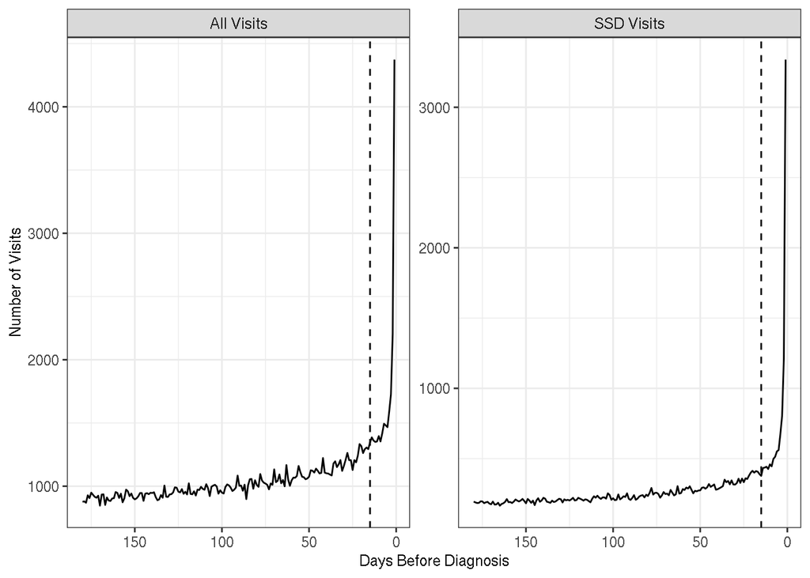

*Curves by cutoff*

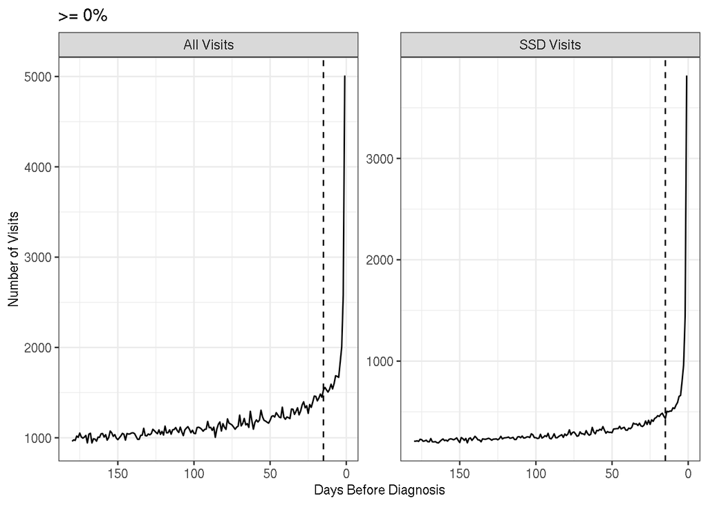

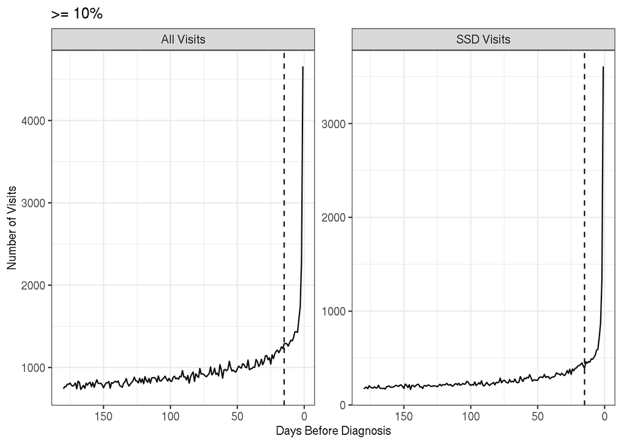

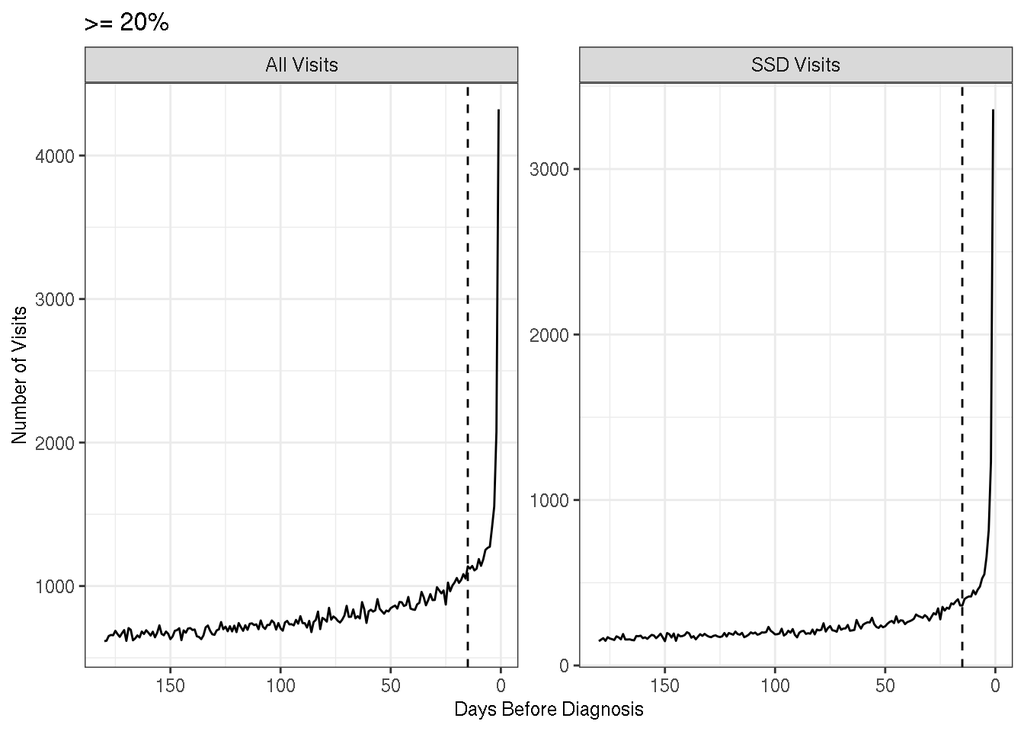

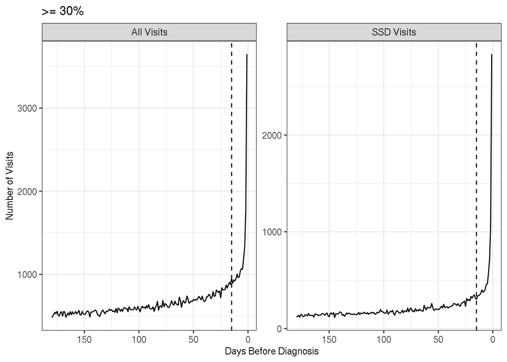

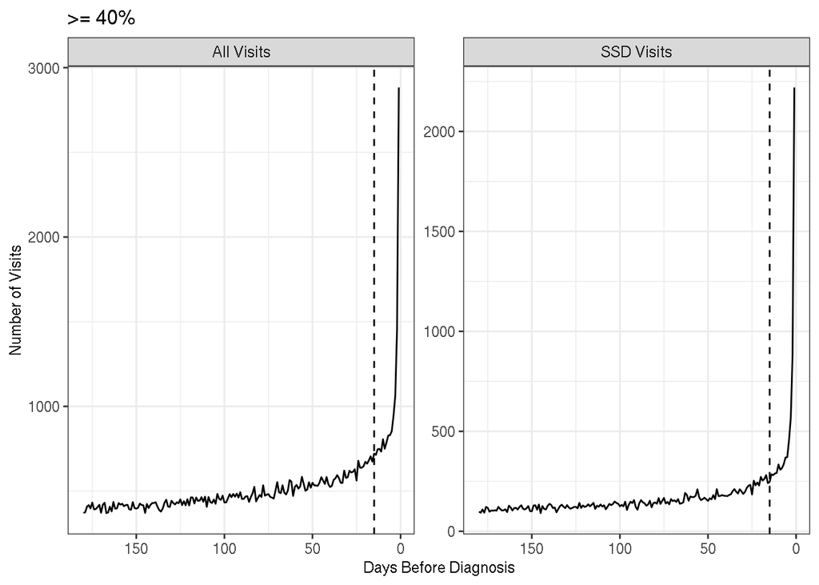

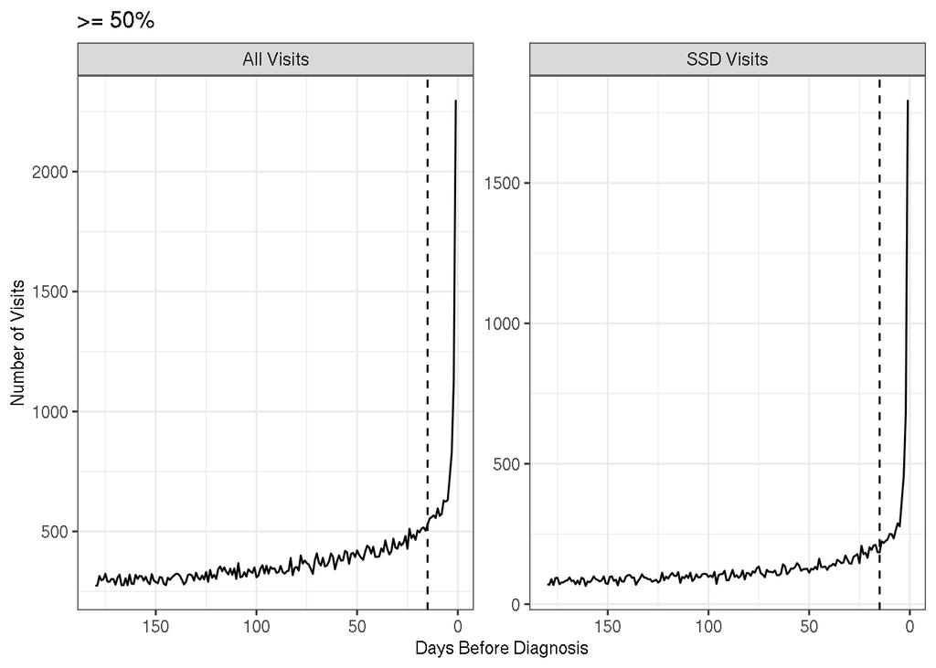

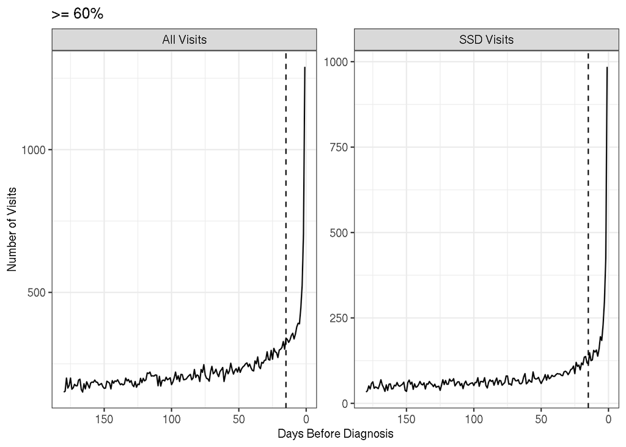

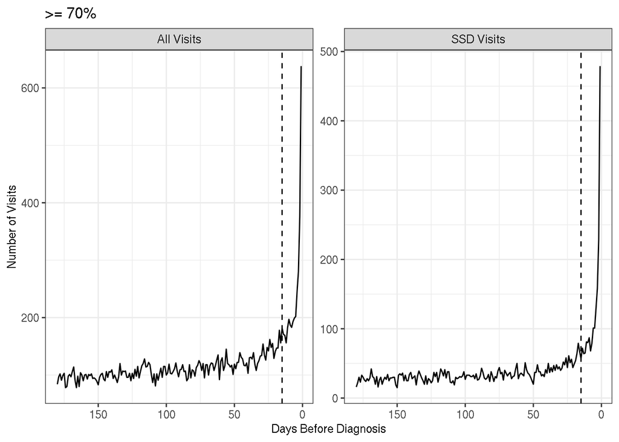

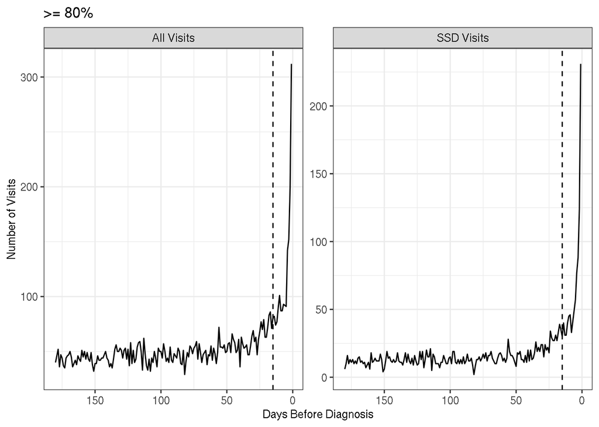

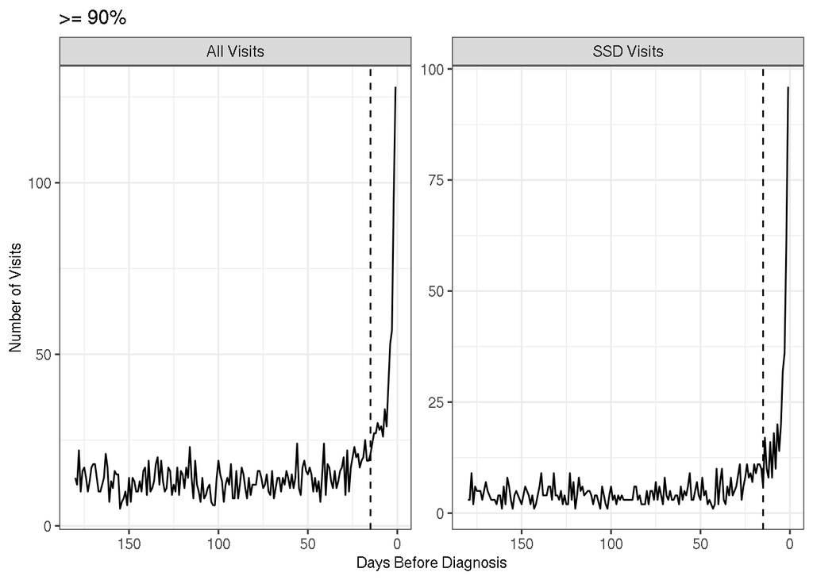

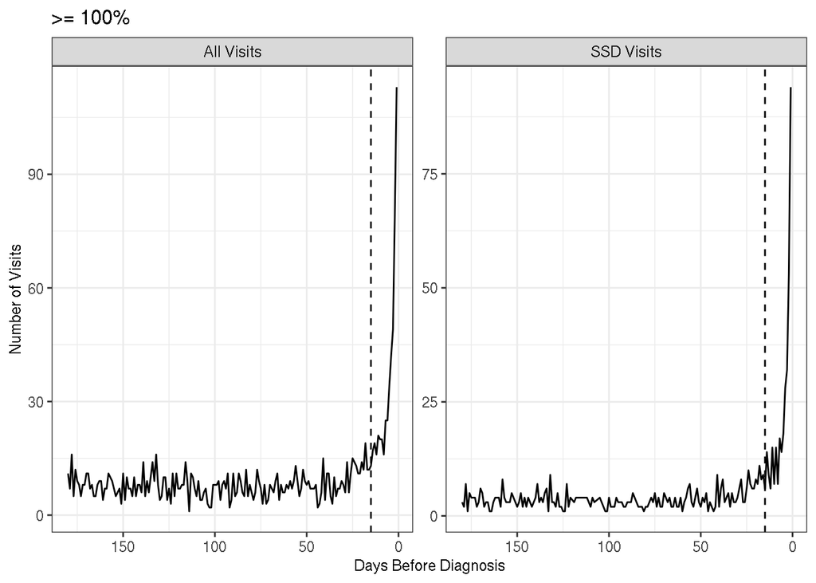